# R Notebook

# LOAD DATASET

```r
hsb2_anova <- read.csv("hsb2.csv")
```

# The datasets’ collection:

https://vincentarelbundock.github.io/Rdatasets/articles/data.html

# Der Datensatz für Pearson, t-Test (unabh.) und ANOVA:

https://vincentarelbundock.github.io/Rdatasets/csv/openintro/hsb2.csv https://vincentarelbundock.github.io/Rdatasets/doc/openintro/hsb2.html siehe auch Anhang für alle Variabeln

# Beschreibung

200 Beobachtungen wurden nach einem Zufallsprinzip im Rahmen einer Umfrage des US-Nationalen Zentrums für Bildungsstatistiken (National Center of Education Statistics) unter Oberstufenschülern (High School and Beyond) durchgeführt.

# Daten:

200 Beobachtungen 11 Variablen

# Einfaktoriellen Varianzanalyse ohne Messwiederholung

Es wird ein Signifikanzniveau von alpha = 0.05 angenommen.

## Was soll untersucht werden?:

Gibt es einen Mittelwertsunterschied bzgl. des Scores in den Sozialwissenschaften, wenn die Schüler einen der drei Programme (Allgemein, akademisch, Berufsausbildung) absolviert haben?

## ANALYSE GLIEDERUNG:

0 Grundlegendes Konzept 1 Hypothese 2 Voraussetzungen 3 Deskriptive Statistik 4 Graphische Darstellung 5 Test auf Varianz-Homogenität (Levenne-Test) 6 Anova 7 Post-Hoc-Test 8 Partielles Eta 9 Effektstärke 10 Aussage 11 Anhang

## Grundlegendes Konzept

Die einfaktorielle Varianzanalyse – auch “einfaktorielle ANOVA”, da in Englisch “Analysis of Variance” – testet, ob sich die Mittelwerte mehrerer unabhängiger Gruppen (oder Stichproben) unterscheiden, die durch eine kategoriale unabhängige Variable definiert werden. Diese kategoriale unabhängige Variable wird im Kontext der Varianzanalyse als “Faktor” bezeichnet. Entsprechend werden die Ausprägungen der unabhängigen Variable “Faktorstufen” genannt, wobei auch der Begriff der “Treatments” gebräuchlich ist. Als “einfaktoriell” wird eine Varianzanalyse bezeichnet, wenn sie lediglich einen Faktor, also eine Gruppierungsvariable, verwendet mehrfaktorielle Varianzanalyse).

Das Prinzip der Varianzanalyse besteht in der Zerlegung der Varianz der abhängigen Variable. Die Gesamtvarianz setzt sich aus der sogenannten “Varianz innerhalb der Gruppen” und der “Varianz zwischen den Gruppen” zusammen. Diese beiden Anteile werden im Rahmen einer Varianzanalyse miteinander verglichen. Die einfaktorielle ANOVA stellt eine Verallgemeinerung des t-Tests für unabhängige Stichproben für Vergleich von mehr als zwei Gruppen (oder Stichproben) dar. Die Fragestellung der einfaktoriellen Varianzanalyse wird oft so verkürzt: “Unterscheiden sich die Mittelwerte einer unabhängigen Variable zwischen mehreren Gruppen? Welche Faktorstufen unterscheiden sich?”

## Hypothese

H1: Es gibt einen Mittelwertsunterschied zwischen dem Programm, dass die Probanden besuchten (Allgemein, akademisch, Berufsausbildung) (prog) bzgl. des Sozialwissenschafts-Scores (socst). M1≠M2≠M3 (für min. einen Vergleich)

H0: Es gibt keinen Mittelwertsunterschied zwischen dem Programm, dass die Probanden besuchten (Allgemein, akademisch, Berufsausbildung) (prog) bzgl. des Sozialwissenschafts-Scores (socst). M1=M2=M3

## Voraussetzungen

Die abhängige Variable ist intervallskaliert -> der Sozialwissenschafst-Score ist metrisch und intervallskaliert Die unabhängige Variable (Faktor) ist kategorial (nominal- oder ordinalskaliert) -> Das Programm ist nominal-skaliert (ggf. ordinal). Die durch den Faktor gebildeten Gruppen sind unabhängig -> Die Gruppen untereinander sind unabh. Die abhängige Variablen ist normalverteilt innerhalb jeder der Gruppen (Ab > 25 Probanden pro Gruppe sind Verletzungen in der Regel unproblematisch) -> siehe Histogramm, Homogenität der Varianzen: Die Gruppen stammen aus Grundgesamtheiten mit annähernd identischen Varianzen der abhängigen Variablen -> siehe Levene-Test

## Deskriptive Statistik

```r
hsb2_anova %>%
group_by(prog) %>%
  summarize(Anzahl = n(), Mittelwert = mean(socst), Median = median(socst), Standardabweichung = sd(socst)) %>%
  mutate_if(is.numeric, round, 2)
```

| prog | Anzahl | Mittelwert | Median | Standardabweichung |
| --- | --- | --- | --- | --- |
| academic | 105 | 56.70 | 56 | 9.17 |
| general | 45 | 50.60 | 51 | 9.31 |
| vocational | 50 | 45.02 | 46 | 10.66 |

Aufsteigenden Reihenfolge bezüglich des Mittelwertes der Scores in den Sozialwissenschaften:

beruflich: M = 45.02, SD = 10.66, n = 50 allgemein: M = 50.60, SD = 9.31, n = 45 akademisch: M = 56.70, SD = 9.17, n = 105

Es gibt einen Mittelwertsunterschied zwischen den Gruppen. Das berufliche Programm (M = 45.02, SD = 10.66, n = 50) zeigt die schlechtesten Scores in den Sozialwissenschaften. Das allgemeine Programm (M = 50.60, SD = 9.31, n = 45) liegt über dem des beruflichen. Am höhsten haben aber Teilnehmer des akademischen Programms gescort (M = 56.70, SD = 9.17, n = 105).

## Graphisch Darstellung

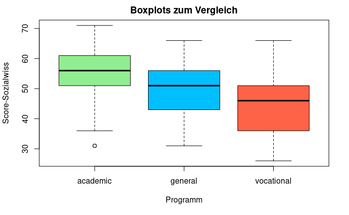

```r
boxplot(hsb2_anova$socst ~ hsb2_anova$prog, main = "Boxplots zum Vergleich", ylab = "Score-Sozialwiss", xlab= "Programm" , col = c("lightgreen", "deepskyblue","tomato"))
```

Im Boxplot sieht man die gleiche Mittelwertverteilung, wie oben in der deskripten Statistik berichtet. Man sieht außerdem, dass es einen Ausreiße bei dem akademischen Programm gibt. Dieser ist aber zu vernachlässigen, da es sich nur um einen handelt. Eindeutige Unterschiede sind im Post-Hoc zwischen dem akademischen und beruflichen Zweig zu erwarten. Bezüglich des allgemeinen und den anderen Programmen könnte die Posthoc Analyse nicht signifikant ausfallen, aufgrund der geringen Mittelwert-Unterschiede.

```
`fun.y` is deprecated. Use `fun` instead.`fun.y` is deprecated. Use `fun` instead.
```

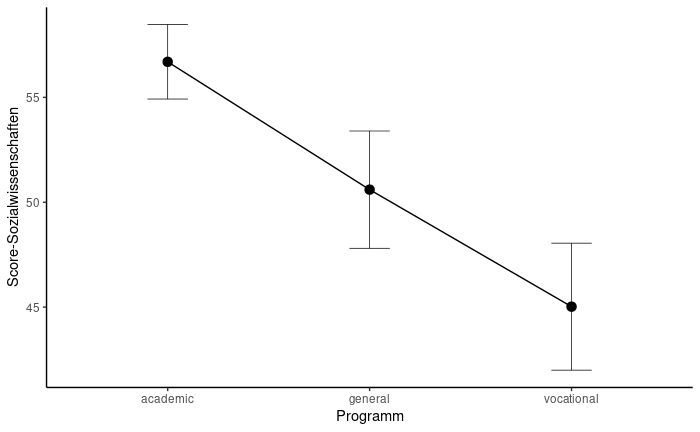

```r
ggplot(hsb2_anova, aes(x=prog, y=socst, group=1))+
  stat_summary(fun.y = mean, geom="point", size=3)+
  stat_summary(fun.y = mean, geom="line")+
  stat_summary(fun.data = mean_cl_normal, geom="errorbar",width=.2, size=.25)+
  labs(x="Programm", y="Score-Sozialwissenschaften")+
  theme_classic()
```

Auch hierl lässt sich, wie beim Boxplot sehen, dass Unterschiede bzgl. der Mittelwerte bestehen.

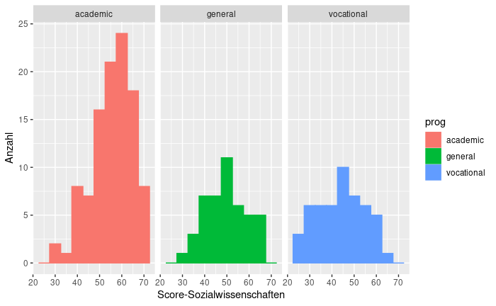

```r
hsb2_anova %>%
  group_by(prog) %>%
  ggplot(aes(socst, color=prog)) +
  geom_histogram(aes(fill = prog), bins = 10) +
  facet_wrap(~prog) +
  theme_grey()+
  labs(x= "Score-Sozialwissenschaften",y = "Anzahl" )
```

Die Daten scheinen normalverteilt zu sein.

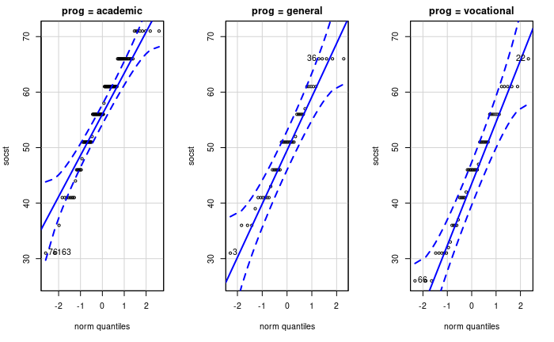

```r
library(car)

qqPlot(socst ~ prog, data=hsb2_anova,
       layout=c(1, 3))
```

Grundsätzlich kann man von einer Normalverteilung ausgehen. Lediglich bei dem akademischen Programm reichen die Punkte über die Kofidenzintervalle hinaus. Entsprechend weiter ist die akademische Gruppe von der Normalverteilung entfernt. Aufgrund der Größe der Stichprobe (n>30) kann dies aber vernachlässigt werden.

## Test auf Varianz-Homogenität (Levenne-Test)

```r
leveneTest(hsb2_anova$socst ~ hsb2_anova$prog, center="mean")
```

```
Levene's Test for Homogeneity of Variance (center = "mean")
       Df F value Pr(>F)
group   2  1.2542 0.2876
      197
```

Der Levenne-Test erweißt sich als nicht signifikant. Die H0 kann nicht verworfen werden. Entsprechend besteht Homogenität der Varianzen und es kann auf eine Korrektur verzichtet werden. (F(2,197) = 1.2542, p = .29)

## Anova

```r
ANOVA <- aov(data=hsb2_anova, socst~prog)
summary(ANOVA)
```

```
             Df Sum Sq Mean Sq F value   Pr(>F)
prog          2   4806    2403   26.11 8.73e-11 ***
Residuals   197  18130      92
---
Signif. codes:  0 ‘***’ 0.001 ‘**’ 0.01 ‘*’ 0.05 ‘.’ 0.1 ‘ ’ 1
```

Das Gesamtmodel erweißt sich als signifikant (F(2,197) = 26.11 , p = 8.73e-11).

Allerdings lässt sich aufgrund dieses Tests nicht bestimmen, welche der drei Gruppen sich signifikant voneinander unterscheiden. Daher wird ein Post-hoc-Test durchgeführt.

## Post-Hoc

```r
TukeyHSD(aov(data=hsb2_anova, socst~prog))
```

```
  Tukey multiple comparisons of means
    95% family-wise confidence level

Fit: aov(formula = socst ~ prog, data = hsb2_anova)

$prog
                          diff       lwr        upr     p adj
general-academic     -6.095238 -10.13179 -2.0586841 0.0013172
vocational-academic -11.675238 -15.56795 -7.7825264 0.0000000
vocational-general   -5.580000 -10.23518 -0.9248188 0.0141324
```

Es wird ersichtlich, dass sich die Programme akademisch und allgemein sowie beruflich bezüglich des Sozialwissenschafts-Scores signifikant unterscheiden. Es können also drei unabhängige/ generalisierbare Gruppen gebildet werden.

Sowohl in der deskrpiten Statistik, als auch im Profildiagramm und dem Boxplot kann man sehen, dass Mittelwertunterschiede zwischen den Gruppen bestehen, wobei akademisch den höchsten Mittelwert aufweist, gefolgt von der allgemeinen Gruppe und mit dem niedrigsten Mittelwert der beruflichen Gruppe.

## Partielles Eta

```r
library(effectsize)
eta <- eta_squared(ANOVA)
```

```
For one-way between subjects designs, partial eta squared is equivalent to eta squared.
Returning eta squared.
```

```r
eta$Eta2
```

```
[1] 0.2095451
```

Das partielle Eta-Quadrat beträgt 0.2095. Das heißt, es wird 20.95% der Variation des Sozialwissenschafts-Score durch die unterschiedlichen Programme erklärt.

## Effektstärke

```r
eff <- sqrt(eta$Eta2 /(1-eta$Eta2))
eff
```

```
[1] 0.5148731
```

Man kann von einem starken Effekt ausgehen (vgl. Cohens 1988). (f = 0.514)

$$\begin{align}
\text{Schwacher Effekt: } 0.10 &< ||f|| < 0.25 \\
\text{Schwacher bis mittlerer Effekt: } 0.25 &= ||f|| \\
\text{Mittlerer Effekt: } 0.25 &< ||f|| < 0.40 \\
\text{Mittlerer bis starker Effekt: }0.40 &= ||f|| \\
\text{Starker Effekt: } 0.40 &< ||f||
\end{align}$$

# Aussage

Das jeweilige schulische Programm hat einen signifikanten Einfluss auf die Scores im Test für die Sozialwissenschaften (F(2,197) = 26.11 , p = 8.73e-11). 20.95% der Streuung der Scores in dem Sozialwissenschaftstest um den Gesamtmittelwert kann durch das Programm, welches die Probanden besuchte haben erklärt werden. Die Effektstärke nach Cohen (1988) liegt bei f = 0.51 und entspricht einem starken Effekt.

Die Post-hoc-Tests mit Tukey zeigen, dass sich drei Gruppen bzgl. des schulischen Programms bilden lassen (alle p < .05). Damit kann festgehalten, werden, dass alle drei Gruppen unabhängige Gruppen bilden und sich signifikant unterscheiden. Personen die ein akademisches Programm besucht haben, zeigen die höchsten Werte bezüglich des Scores in den Sozialwissenschaften (M = 56.70, SD = 9.17, n = 105), gefolgt von den allgemeinem (M = 50.60, SD = 9.31, n = 45) und dem beruflichen Programm (M = 45.02, SD = 10.66, n = 50) (vgl. hierzu auch das Profildiagramm). Die H0 kann verworfen werden.

### Anhang:

VARIABELN UND BEDEUTUNG:

id Studenten ID

gender Geschlecht - männlich/weiblich

race Ethnie: Afroamerikaner, Asiaten, Hispanic, und Weiß.

ses Sozioökonomischer Status der Familien der Befragten: Niedrig, mittel, hoch.

schtyp Schultyp: Öffentlich und Privat (Schulen)

prog Programmtyp: Allgemein, akademisch , and Berufsausbildung.

read Standardisierte Lesescore.

write Standardisierte Schreibscore

math Standardisierte Mathescore

science Standardisierte Naturwissenschaftsscore

socst Standardisierte Sozialwissenschaftsscore